# Lab 03

Giancarlo M. Correa

En este manual veremos los aspectos básicos de una regresión lineal, quizá el análisis estadístico más utilizado en ecología.

Una regresión lineal simple establece una relación lineal entre dos variables, donde la ecuación que la define es:

$y=\alpha +\beta x+\epsilon$

Donde:

- $y$ es la variable respuesta o dependiente.
- $x$ es la variable independiente o predictora.
- $\alpha$ es el intercepto y describe el valor que toma $y$ cuando $x$ es igual a cero. Normalmente carece de significado ecológico, por lo que nos centraremos en $\beta$.
- $\beta$ es la pendiente. Describe en cuantas unidades aumenta $y$ cuando $x$ aumenta en una unidad.
- $\epsilon$ es el error y sigue una distribución normal $N(0,\sigma ^2)$. Representa la varianza de la variable $y$ para un valor de $x$.

Para entender mejor el error (también conocido como residuales), podemos decir que para cierto valor de $x$, el correspondiente valor de $y$ va a estar distribuido con media $\alpha + \beta x$ y con varianza $\sigma ^2$. Mientras $\sigma ^2$ sea mas grande, el ajuste de la línea de regresión será peor.

Si $\beta >0$, entonces las variables $x$ e $y$ tienen una relación positiva, si $\beta <0$, entonces las variables $x$ e $y$ tienen una relación negativa, y si $\beta =0$, entonces las variables $x$ e $y$ no están relacionadas.

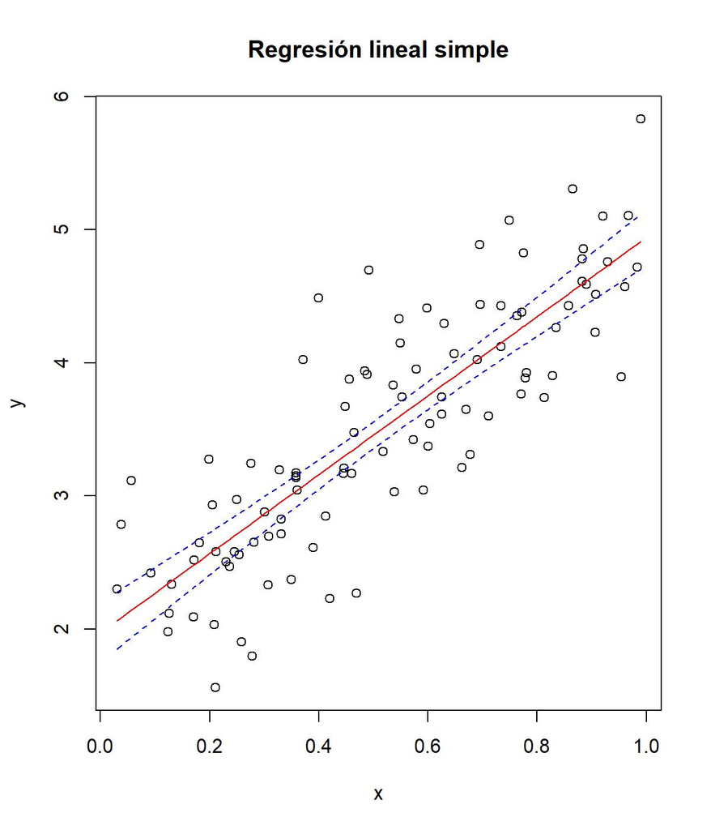

Regresión lineal simple. Línea roja es la línea de regresión y las líneas azules es el intervalo de confianza. Puntos son observaciones.

## 0.1 Ajuste de una línea de regresión simple

Normalmente se realiza por el método de mínimos cuadrados. Si asumimos:

$S=\sum_{i=1}^n d_i^2$

Donde $d_i$ es la distancia entre observaciones $(x_i, y_i)$ y puntos sobre la línea de regresión $(x_i,\hat{y_i})$. Entonces, el objetivo es minimizar $S$.

Asumamos que $a$ y $b$ son los mejores estimados que podemos obtener para $\alpha$ y $\beta$, entonces:

$\hat{y_i} = a+bx_i$

Vamos a realizar paso a paso el ajuste de una línea de regresión simple. Definamos los siguientes términos:

$L_{xx}=\sum_{i=1}^n(x_i-\bar{x})^2$

$L_{yy}=\sum_{i=1}^n(y_i-\bar{y})^2$

Estos son la suma de cuadrados corregidos. Ahora:

$L_{xy}=\sum_{i=1}^n(x_i-\bar{x})(y_i-\bar{y})$

Esta es la suma de productos cruzados corregidos. Nos damos cuenta que cuando $L_{xy}$ es positivo, entonces $\beta >0$, y cuando $L_{xy}$ es negativo, entonces $\beta <0$.

Se puede probar (dejaremos la prueba de esto para una clase de estadística) que las siguientes estimaciones minimizan la suma de cuadrados de los residuales:

$b=\frac{L_{xy}}{L_{xx}}$

$a=\bar{y}-b\bar{x}$

Donde $\bar{y}$ y $\bar{x}$ representa la media de los valores de $y$ y $x$, respectivamente. Con estos valores, podemos obtener los predichos:

$\hat{y}=a+bx$

Vemos que el punto $(x,a+bx)$ debe estar siempre sobre la línea de regresión. Ahora, vemos que:

$y=a+bx = \bar{y}-b\bar{x}+bx=\bar{y}+b(x-\bar{x})$

Entonces:

$y-\bar{y}=b(x-\bar{x})$

Podemos identificar dos componentes en la línea de regresión:

1. Componente residual: $y_i - \hat{y_i}$
2. Componente de regresión: $\hat{y_i}-\bar{y}$

Para tener un buen ajuste, siempre esperamos que el componente residual sea menor que el componente de regresión. Ahora definamos tres suma de cuadrados:

1. Suma de cuadrados total ($TSS$): $\sum_{i=1}^n(y_i - \bar{y})^2$
2. Suma de cuadrados de la regresión ($RSS$): $\sum_{i=1}^n(\hat{y_i} - \bar{y})^2$
3. Suma de cuadrados de los residuos ($ESS$): $\sum_{i=1}^n(y_i - \hat{y})^2$

Y vemos que se cumple que $TSS = RSS + ESS$.

### 0.1.1 Prueba F

Podemos implementar una prueba F con $RSS$ y $ESS$. Aquí $H_0: \beta = 0$ y $H_A:\beta \neq 0$, y el estadístico es:

$F = \frac{RMS}{EMS}$,

Donde $RMS=RSS/k$, y $k$ es el número de variables independientes. Además, $EMS =ESS/(n-k-1)$, y $n$ es el número de observaciones.

En este caso, para un nivel de significancia $\alpha$:

- $F>F_{1,n-2,1-\alpha}$ rechazamos $H_0$
- $F \leq F_{1,n-2,1-\alpha}$, entonces fallamos en rechazar $H_0$

### 0.1.2 One-way ANOVA

Esta es una prueba de hipótesis que se utiliza cuando se quiere comparar la media de alguna variable entre diferentes grupos o tratamientos. Se asume que la distribución por tratamiento de esta variable tiene una distribución normal y las mismas varianzas.

*Ejemplo*: Se tiene la variable longitud total de una muestra de peces que han sido sometidas a tres tratamientos de temperatura: baja, media, alta (3 tratamientos o grupos). La pregunta que se quiere responder con un ANOVA es si las medias de longitud total entre estos grupos es estadísticamente diferente o no. $H_0: \mu_1=\mu_2=...=\mu_k$ y $H_A: \mu_1\neq\mu_2\neq...\neq\mu_k$.

El procedimiento para realizar esta prueba de hipótesis es similar a la que acaba de ser descrita con la prueba F.

### 0.1.3 Prueba t

Para un nivel de significancia de $\alpha$:

- $t>t_{n-2,1-\alpha/2}$, rechazamos $H_0$
- $-t_{n-2,1-\alpha /2} \leq t\leq t_{n-2,1-\alpha /2}$, entonces fallamos en rechazar $H_0$.

Los resultados de esta prueba t es la que observamos para cada parámetro cuando hacemos `summary(modelo)`, donde `modelo` representa la regresión lineal en R.

También podemos definir $R^2$, un indicador muy utilizado en una regresión lineal que da información acerca de la bondad de ajuste del modelo. Es la proporción de la varianza de $y$ que es explicada por $x$.

$R^2=\frac{RSS}{TSS}$

Donde $R^2$ toma valores entre 0 y 1.

El error estándar (una medida que nos dice que tan lejos están los parámetros estimados del valor real en la población) de los parámetros:

$se(b)=\sqrt{\frac{EMS}{L_{xx}}}$

$se(a)=\sqrt{EMS(\frac{1}{n}+\frac{\bar{x}^2}{L_{xx}})}$

Donde los intervalos de confianza para los parámetros estimados son:

$b \pm t_{n-2,1-\alpha /2}se(b)$

$a \pm t_{n-2,1-\alpha /2}se(a)$

Los intervalos de confianza (al $100(1-\alpha)\%$) para los valores sobre la línea de regresión estimada:

$se_1(\hat{y}) = \sqrt{EMS[\frac{1}{n}+\frac{(x-\bar{x})^2}{L_{xx}}]}$

$\hat{y} \pm t_{n-2,1-\alpha /2}se_1(\hat{y})$

Los intervalos de predicción (para valores que no fueron tomados al momento de hacer la regresión, es decir, valores de $x$ donde se quiere predecir $y$) es (al $100(1-\alpha)\%$):

$se_2(\hat{y})=\sqrt{EMS[1+\frac{1}{n}+\frac{(x-\bar{x})^2}{L_{xx}}]}$

$\hat{y} \pm t_{n-2,1-\alpha /2}se_2(\hat{y})$

Es importante mencionar que los intervalos de predicción no son los mismos que los intervalos de confianza. Los intervalos de predicción define el rango en que un nuevo individuo (o valor de $x$) donde caerá. Por otro lado, el intervalo de confianza define el rango probable de valores asociados con los parámetros del modelo.

### 0.1.4 Supuestos de una regresión lineal

Existen tres supuestos importante que debemos tomar en cuenta al momento de hacer una regresión lineal:

1. Para cualquier valor de $x$, el valor correspondiente de $y$ tiene un valor promedio $\alpha + \beta x$, la cual es una función lineal de $x$.
2. Para cualquier valor de $x$, el valor correspondiente de $y$ esta normalmente distribuido alrededor de $\alpha + \beta x$ con la misma varianza $\sigma ^2$ para cualquier $x$.
3. Para dos puntos cualquiera $(x_1,y_1)$, $(x_2,y_2)$, los términos de error $\epsilon_1, \epsilon_2$ son independientes uno del otro.

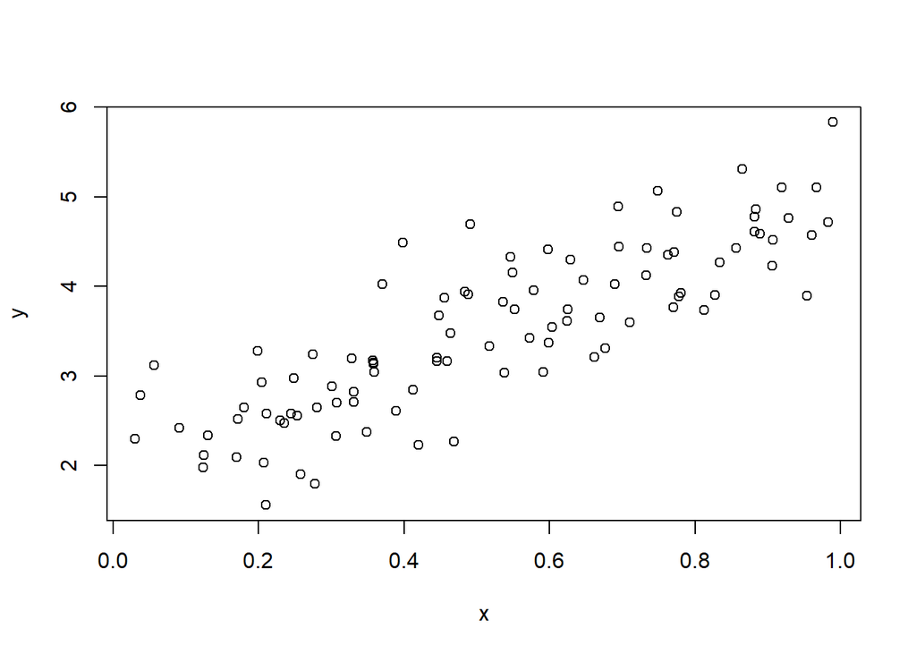

```r
#Vamos a observar paso a paso como obtenemos todos los valores que
# acabamos de describir

# Activamos las librerias que vamos a utilizar
require(e1071)
require(MASS)
require(pracma)
require(maps)
require(mapdata)
require(corrplot)
require(PerformanceAnalytics)
require(ggplot2)
require(dplyr)

# Simular datos:
set.seed(100)
x = runif(100)
n = length(x)
y = 3*x+2+0.5*rnorm(n)

# Observemos lo que hemos simulado:
plot(x, y)
```

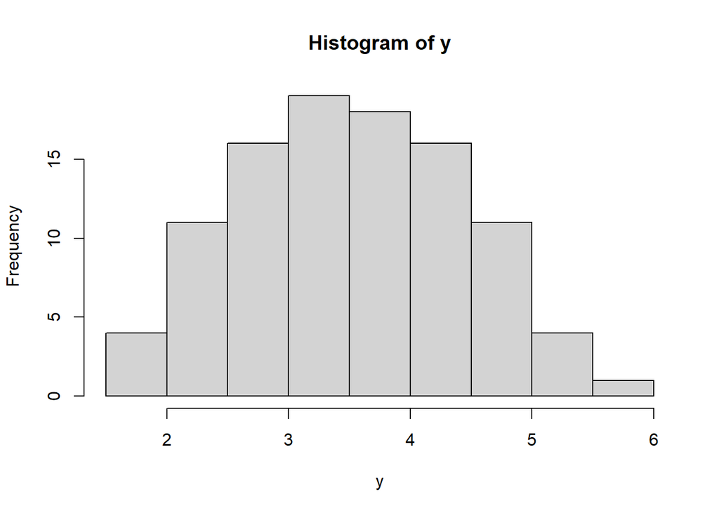

```r
# Veamos la distribucion de la variable respuesta:
hist(y)
```

```r
# Comenzemos a calcular los parametros paso por paso:
var_x = var(x)
var_y = var(y)

cov_xy = cov(x,y)

sd_x = sd(x)
sd_y = sd(y)

Lxx = sum((x-mean(x))^2)
Lyy = sum((y-mean(y))^2)
Lxy = sum((x-mean(x))*(y-mean(y)))

# Calculemos la pendiente y intercepto:
slope = Lxy/Lxx # pendiente
intercept = mean(y)-slope*mean(x) # intercepto

# Predicciones:
y_pred = intercept + slope*x

# Calcular residuales:
res = y - y_pred

# calculamos TSS:
tss = sum((y-mean(y))^2)

# Calcular RSS: (componente de regresion)
rss = sum((y_pred-mean(y))^2)

# Calcular ESS: (componente residual)
ess = sum(res^2)

k = 1 # Numero de variables independientes
# Calcular RMS:
rms = rss/k

# Calcular EMS:
ems = ess/(n-k-1)

# Corremos prueba F para evaluar la pendiente
# Pendiente de referencia:
beta_0 = 0 # H0: Beta = 0

# Estadistico:
F_stat = rms/ems

# Encontramos valor critico
critical_value = qf(p = 1-0.05, df1 = k, df2 = n-k-1)

F_stat > critical_value # Rechazamos la hipotesis nula?
```

```
## [1] TRUE
```

```r
# Calculamos el p-value:
p_value = 1 - pf(q = F_stat, df1 = k, df2 = n-k-1) # acumulada (p-value)

# --------------
# Error estandar de pendiente
se_slope = sqrt(ems/Lxx)

# Error estandar de intercepto
se_intercept = sqrt(ems*(1/n + (mean(x)^2)/Lxx))


# Corremos prueba t para evaluar la pendiente (metodo alternativo)
# Pendiente de referencia:
beta_0 = 0 # H0: Beta = 0

# Estadistico:
t_stat_slope = (slope-beta_0)/se_slope

# Encontramos valor critico
critical_value = qt(p = 1-0.05/2, df = n-k-1)

abs(t_stat_slope) > critical_value # Rechazamos la hipotesis nula?
```

```
## [1] TRUE
```

```r
# Calculamos el p-value:
p_value = 2*(1-pt(q = t_stat_slope, df = n-k-1)) # acumulada (p-value)

# De igual forma lo podemos hacer para el intercepto
# Pendiente de referencia:
intercept_0 = 0 # H0: Alpha = 0

# Estadistico:
t_stat_int = (intercept-intercept_0)/se_intercept

# Encontramos valor critico
critical_value = qt(p = 1-0.05/2, df = n-k-1)

abs(t_stat_int) > critical_value # Rechazamos la hipotesis nula?
```

```
## [1] TRUE
```

```r
# Calculamos el p-value:
p_value = 2*(1-pt(q = t_stat_int, df = n-k-1)) # acumulada (p-value)

# Tambien podemos calcular los CI de los parametros estimados:
# CI de la pendiente:
slope - qt(p = 1 - 0.05/2, df = n-k-1)*se_slope # limite inferior
```

```
## [1] 2.582239
```

```r
slope + qt(p = 1 - 0.05/2, df = n-k-1)*se_slope # limite superior
```

```
## [1] 3.353076
```

```r
# CI de la intercepto:
intercept - qt(p = 1 - 0.05/2, df = n-k-1)*se_intercept # limite inferior
```

```
## [1] 1.748796
```

```r
intercept + qt(p = 1 - 0.05/2, df = n-k-1)*se_intercept # limite superior
```

```
## [1] 2.197097
```

```r
# Terminamos con la prueba de hipotesis

# Calculamos R2
R_sq = rss/tss

# Correlacion:
r = cov_xy/(sd_x*sd_y)
r^2 # Debe darnos R_sq
```

```
## [1] 0.7043571
```

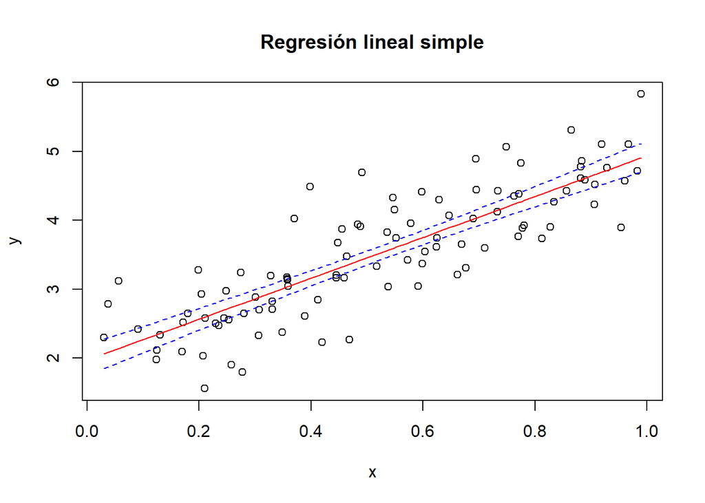

```r
# Tambien podemos calcular R_sq ajustado:
r_adj = sqrt(1-((1-r^2)*(n-1)/(n-2)))
Rsq_adj = r_adj^2

# Ahora calculamos el CI de los valores y usados en la regresion
se1_y_pred = sqrt(ems*((1/n)+((x-mean(x))^2)/Lxx))
y_up = y_pred + qt(p = 1-0.05/2, df = n-k-1)*se1_y_pred
y_low = y_pred - qt(p = 1-0.05/2, df = n-k-1)*se1_y_pred

# Hacemos una figura para observar CI
plot(x,y,main='Regresión lineal simple')
lines(sort(x),y_pred[order(x)], col = 'red')
lines(sort(x),y_up[order(x)],lty=2, col = 'blue')
lines(sort(x),y_low[order(x)],lty=2, col = 'blue')
```